# Statistical inference with the GSS data

## Setup

### Load packages

```r
library(ggplot2)
library(dplyr)
library(statsr)
```

### Load data

```r
load("gss.Rdata")
```

## Part 1: Data

The target population of the GSS is English-speaking persons 18 years of age or over who live in households in the US (from 2006, Spanish-speakers were added to the target population). Each survey is an independently drawn sample of the target population. The GSS covers different geographical areas (urban, suburban, and rural) so that persons from different geographical areas can be covered in the survey. The GSS data is collected through a survey which is conducted with a face-to-face interview. This indicates that this is an observational study; interviewers collect data from a randomly selected adults who participate through face-to-face interview. As the data is simply collected as it is through sets of questions, there is no manipulation by interviewers. Therefore, the sample sizes dealt in the below research question indicate that the study is generalizable to the population in the US, because the data is collected from large population over 40 years by random sampling. On the other hand, since observational studies do not control any confounding variable, cause-and-effect conclusions between variables cannot be made based on the data.

However, it is important to note that since the only way to collect the data is through face-to-face interviews, those who were not at home when interviewers visited them (although interviewers tried to visit them after 3 P.M.) and those with certain job categories which do not allow them to be around the time of visits. Also, it is hard to capture responses from single-person households.

The fact that the survey used independent random sampling and the observations consist of fewer than 10% of the population ensures that the sample observations are independent. We can assume that the population distribution is not strongly skewed taking into account the generalizability of the data mentioned above. Also, there are more than 30 independent observations. All these satisfied conditions allow us to use statistical inference when answering below research question.

## Part 2: Research question

This question is designed to study a relationship between respondents’ self-identified economic class (the variable ‘class’ as an explanatory variable) and their average hours of watching tv per day (the variable ‘tvhours’ as a response variable). Since I have read before that people belonging to higher economic class tend to not spend time watching tv but do other ‘productive’ activities such as, reading, exercising, or spending time with family, this question seeks to explore whether belonging to a certain economic class makes a difference in one’s average hours of watching tv per day.

## Part 3: Exploratory data analysis

First of all, we study our explanatory variable ‘class’ which indicates respondents’ self-identified economc classes. Since we are only interested in those who self-identified their economic classes, I dropped “No Class” level from the explanatory variable “Class.”

```r
gss <- gss %>%
filter(class != "No Class") %>%
droplevels()
```

In order to see the distribution of the variable “class”, I created a histogram out of the variable.

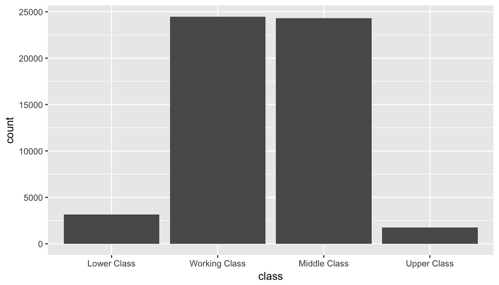

```r
ggplot(gss, aes(x = class)) + geom_bar()
```

To see specific numbers of each level, I checked with the table() function.

```r
with(gss, table(class))
```

```
## class
##   Lower Class Working Class  Middle Class   Upper Class
##          3147         24458         24289          1741
```

Above histogram and table show that the numbers of those who identified themselves as “Working Class” and “Middle Class” are much higher than the numbers of those who identified themselves as “Lower Class” or “Upper Class.”

To explore the response variable ‘tvhours’, which is numerical, I first used the summary function.

```r
with(gss, summary(tvhours))
```

```
##    Min. 1st Qu.  Median    Mean 3rd Qu.    Max.    NA's
##   0.000   2.000   2.000   2.969   4.000  24.000   20760
```

Then, I made a plot to see the distribution of the variable. The plot shows that the distribution is right-skewed.

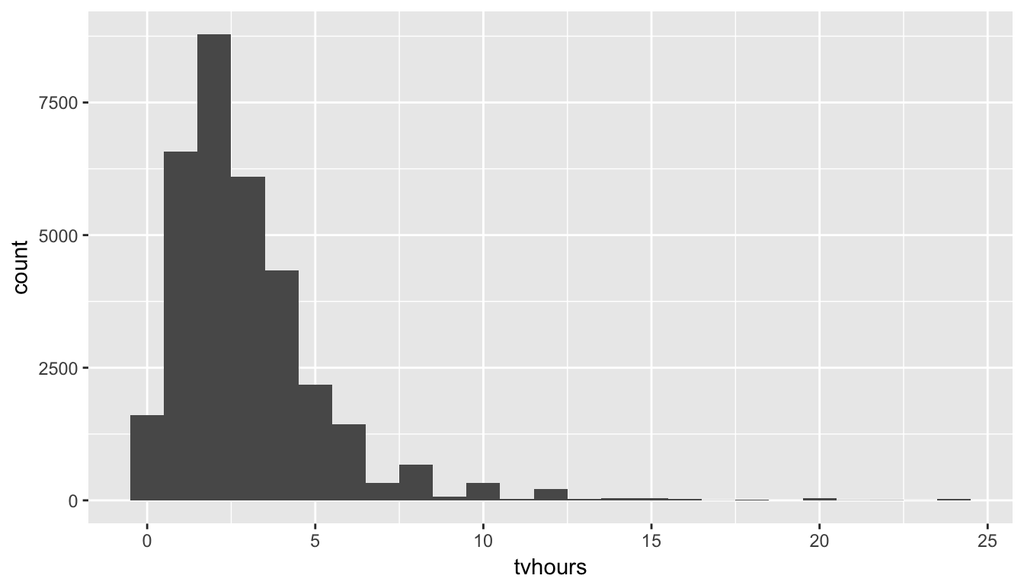

```r
ggplot(gss, aes(x = tvhours)) + geom_histogram(binwidth = 1)
```

Now, to see the relationship between the two variables ‘class’ and ‘tvhours’, I made a boxplot to compare each social level (class) side-by-side in relation to the average hours per day watching tv (tvhours).

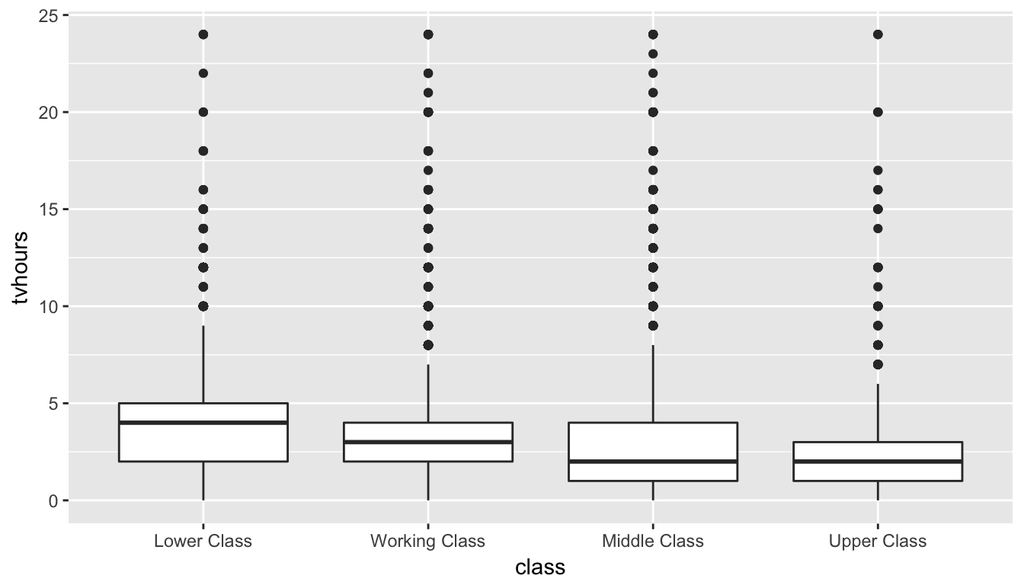

```r
ggplot(gss, aes(x = class, y = tvhours)) + geom_boxplot()
```

The distribution of each class level is right-skewed, I wanted to compare each social class’s median and mean to find out how far apart they are from each other. I used ‘with’ function to get each social class’s median and mean.

```r
with(gss, by(tvhours, class, mean, na.rm = TRUE))
```

```
## class: Lower Class
## [1] 4.096163
## --------------------------------------------------------
## class: Working Class
## [1] 3.023464
## --------------------------------------------------------
## class: Middle Class
## [1] 2.791138
## --------------------------------------------------------
## class: Upper Class
## [1] 2.568326
```

```r
with(gss, by(tvhours, class, median, na.rm = TRUE))
```

```
## class: Lower Class
## [1] 4
## --------------------------------------------------------
## class: Working Class
## [1] 3
## --------------------------------------------------------
## class: Middle Class
## [1] 2
## --------------------------------------------------------
## class: Upper Class
## [1] 2
```

This shows that mean and median of the average hour of watching tv per day is the highest for Lower Class with 4.096 and 4 respectively, working class with 3.023 and 3 respectively, middle class with 2.791 and 2 respectively, and upper class with 2.568 and 2, respectively. This comparison between the means and medians shows that the difference is relatively small.

The best method to conduct statistical inference of comparing means of more than 3 groups is ANOVA. In part 4, we will check the conditions for ANOVA, and if all the conditions are satisfied we will conduct statistical inference test with ANOVA method.

## Part 4: Inference

The hypothesis for testing is whether the average hours per day watching tv of social classes differ between at least one pair of social classes.

$H_0: \mu_{lower} = \mu_{working} = \mu_{middle} = \mu_{upper}$; $H_A$: the average hours per day watching tv differ between at least one pair of social classes

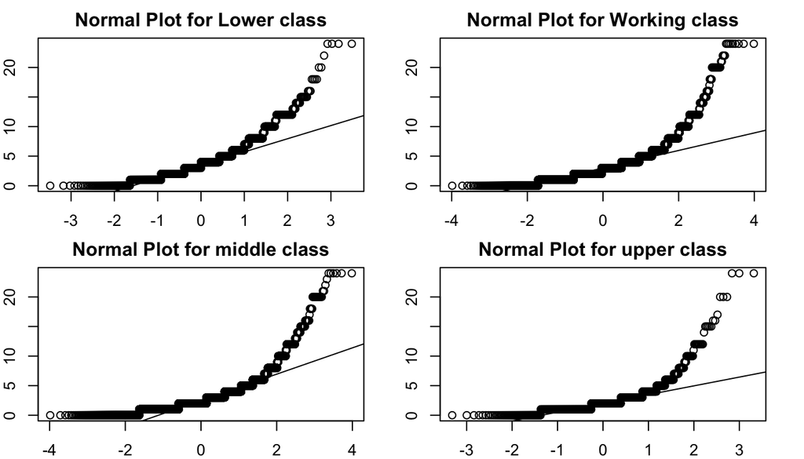

```r
par(mfrow=c(2, 2), mar=c(2, 2, 2, 2))
qqnorm(gss[which(gss$class == "Lower Class"),]$tvhours,main = "Normal Plot for Lower class")
qqline(gss[which(gss$class == "Lower Class"),]$tvhours)
qqnorm(gss[which(gss$class == "Working Class"),]$tvhours,main = "Normal Plot for Working class")
qqline(gss[which(gss$class == "Working Class"),]$tvhours)
qqnorm(gss[which(gss$class == "Middle Class"),]$tvhours,main = "Normal Plot for middle class")
qqline(gss[which(gss$class == "Middle Class"),]$tvhours)
qqnorm(gss[which(gss$class == "Upper Class"),]$tvhours,main = "Normal Plot for upper class")
qqline(gss[which(gss$class == "Upper Class"),]$tvhours)
```

```r
with(gss, by(tvhours, class, summary, na.rm = TRUE))
```

```
## class: Lower Class
##    Min. 1st Qu.  Median    Mean 3rd Qu.    Max.    NA's
##   0.000   2.000   4.000   4.096   5.000  24.000    1140
## --------------------------------------------------------
## class: Working Class
##    Min. 1st Qu.  Median    Mean 3rd Qu.    Max.    NA's
##   0.000   2.000   3.000   3.023   4.000  24.000    9499
## --------------------------------------------------------
## class: Middle Class
##    Min. 1st Qu.  Median    Mean 3rd Qu.    Max.    NA's
##   0.000   1.000   2.000   2.791   4.000  24.000    9485
## --------------------------------------------------------
## class: Upper Class
##    Min. 1st Qu.  Median    Mean 3rd Qu.    Max.    NA's
##   0.000   1.000   2.000   2.568   3.000  24.000     636
```

We first create the anova table to get F value, test statistic for ANOVA, and p-value, which is area under the F curve with degrees of freedom of groups and residuals.

```r
anova(lm(tvhours ~ class, data = gss))
```

```
## Analysis of Variance Table
##
## Response: tvhours
##              Df Sum Sq Mean Sq F value    Pr(>F)
## class         3   3240 1079.99  198.55 < 2.2e-16 ***
## Residuals 32871 178794    5.44
## ---
## Signif. codes:  0 '***' 0.001 '**' 0.01 '*' 0.05 '.' 0.1 ' ' 1
```

Observing the output of the above ANOVA table, we see that the F statistic is 198.55 with a p-value 2.2e-16, which is a very small value. Generally we set up $\alpha$ = 0.05 as a significance level. Therefore, we clearly reject the null hypothesis of equal means for all 4 economic classes. That is, the data provide convincing evidence that at least one pair of population means are different from each other. However, the ANOVA test does not provide us with the information of which ones differ from each other. Thus, additional analysis is required which can be conducted with pairwise comparisons utilizing a modified significance level, Bonferroni correction. Since our Bonferroni correction will be 0.05 divided by 6 ($\alpha$ divided by the number of comparisons), we will get a new significance level of 0.0083. Then I ran the pairwise comparisons to generate a table to compare each average hour per day watching tv of economic class to the others. All below null hypotheses (with alternative hypotheses) can be tested with the table:

$H_0: \mu_{lower} = \mu_{working}$; $H_A: \mu_{lower} \ne \mu_{working}$;

$H_0: \mu_{lower} = \mu_{middle}$; $H_A: \mu_{lower} \ne \mu_{middle}$;

$H_0: \mu_{lower} = \mu_{upper}$; $H_A: \mu_{lower} \ne \mu_{upper}$

$H_0: \mu_{working} = \mu_{middle}$; $H_A: \mu_{working} \ne \mu_{middle}$;

$H_0: \mu_{working} = \mu_{upper}$; $H_A: \mu_{working} \ne \mu_{upper}$;

$H_0: \mu_{middle} = \mu_{upper}$; $H_A: \mu_{middle} \ne \mu_{upper}$;

```r
pairwise.t.test(gss$tvhours, gss$class, p.adj="bonferroni")
```

```
##
##  Pairwise comparisons using t tests with pooled SD
##
## data:  gss$tvhours and gss$class
##
##               Lower Class Working Class Middle Class
## Working Class < 2e-16     -             -
## Middle Class  < 2e-16     < 2e-16       -
## Upper Class   < 2e-16     2.3e-09       0.013
##
## P value adjustment method: bonferroni
```

Above pairwise t test table demonstrates that we rejected all the null hypotheses written above except the null hypothesis ‘the average hour per day watching tv of American middle class is the same as that of American upper class’:

$H_0: \mu_{middle} = \mu_{upper}$; $H_A: \mu_{middle} \ne \mu_{upper}$;